# Part I - Ford GoBike System Data Exploration

## by (Damla Cörüt)

## Investigation Overview

In this report, we will analyze a bike-sharing system covering the greater San Francisco Bay area.

We will mostly be focused on durations of trips what effects them the most. Also we will see the trip counts and durations relationship with user types.

## Dataset Overview

The data set includes information about individual rides made in a bike-sharing system covering the greater San Francisco Bay area.The data set includes informations about members and also the trip itself.

## General Distrubution of Durations

First let's take a look at the general distrubution of our duration data to see the avarege durations of trips.

Majority of the trips takes under 20 minute. And trips longer then an hour is quite rare.

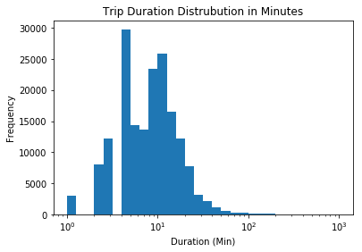

```python
binedges = 10**np.arange(0 , 3+0.1 , 0.1)
plt.xticks([10,20,30,40,50,60],[10,'yirmi','30','40','50','60']);
plt.hist(data = trips , x = 'duration_min' , bins = binedges);
plt.title('Trip Duration Distrubution in Minutes')
plt.xlabel('Duration (Min)');
plt.ylabel('Frequency')
plt.xscale('log');
```

## The relationship between duration, user types and start hours

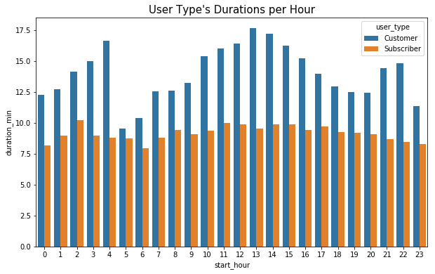

```python
plt.figure(figsize=(10,6))
plt.title("User Type's Durations per Hour", fontsize=15)
plt.xlabel('start_hour')
plt.ylabel('duration_min')
sb.barplot(data=trips, x='start_hour', y='duration_min', ci=None, hue='user_type');
```

## The relationship between duration, user types and days

Again in this part we see that customers have more trip durations in general. In addition to that we get to see they tend to take longer trips on weekends.

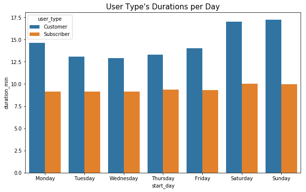

```python
plt.figure(figsize=(10,6))
plt.title("User Type's Durations per Day", fontsize=15)
plt.xlabel('start_day')
plt.ylabel('duration_min')
sb.barplot(data=trips, x='start_day', y='duration_min',order=days, ci=None, hue='user_type')
```

## The relationship between trip days and subscription types

There isn't a huge change among customers between the days. But Subscribers are more likely to use bike system during weekdays, specially on tuesdays and thursdays

```
Text(0,0.5,'Frequency')
```

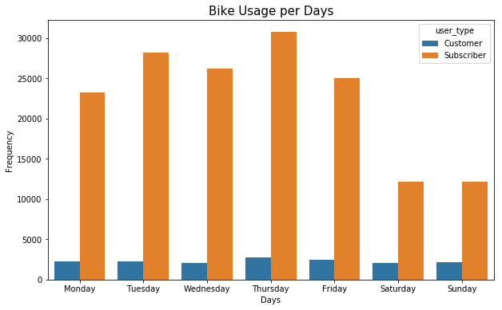

```python
plt.figure(figsize=(10,6))
plt.title('Bike Usage per Days', fontsize=15)
sb.countplot(data=trips, x='start_day', order=days, hue='user_type')
plt.xlabel('Days')
plt.ylabel('Frequency')
```